# Praca Domowa 3 - Raport

Adam Majczyk, Aleksander Malinowski, Damian Skowroński

## Wprowadzenie

Przeprowadzone eksperymenty miały sprawdzić, czy warto tworzyć wykresy zgodnie z przyjętymi dobrymi praktykami, to znaczy czy są one czytelniejsze. Żeby to sprawdzić przeprowadziliśmy ankietę wśród 17 osób, którym pokazywaliśmy wykresy “dobre” i “złe”, i zadawaliśmy im pytania.

## Eksperymenty:

### Eksperyment 1

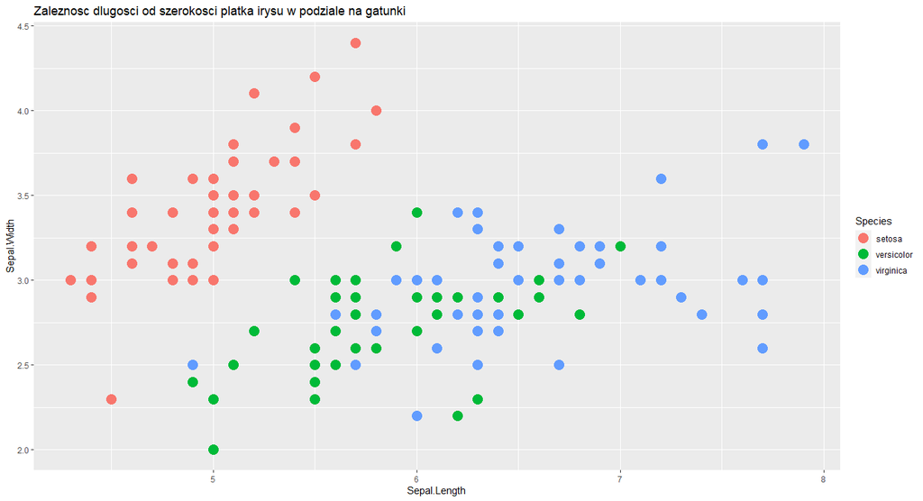

*Wykres 1.1*

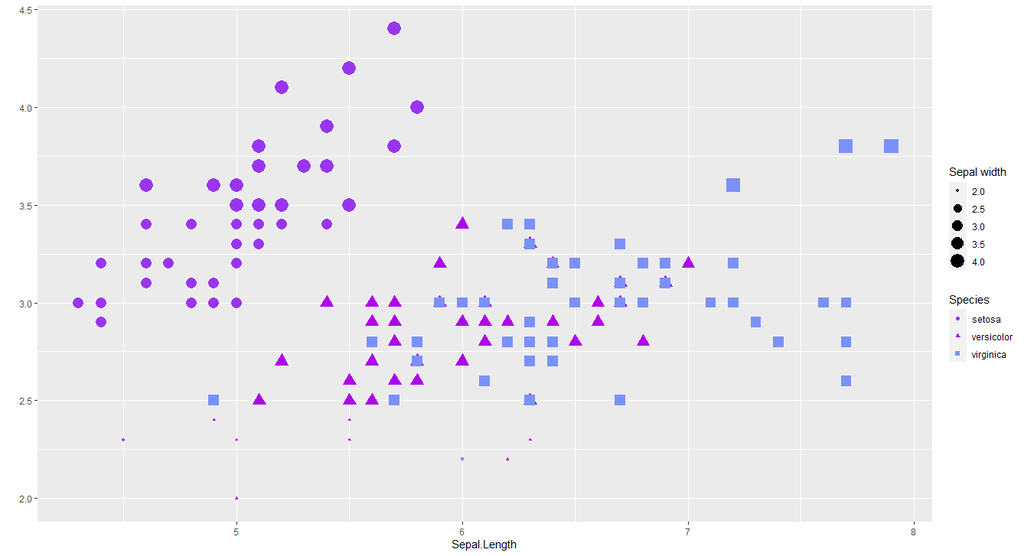

*Wykres 1.2*

**Celem eksperymentu było:**

- zbadanie jak sposoby przedstawiania grupowania (kształt i kolor vs sam kolor)
- zbadanie który sposób prezentacji wielkości jednej ze zmiennych jest lepszy (dane na temat Sepal.Width są powielone na wykresie 1.2, brakuje tam opisu osi OY).

**Postawione pytanie ankeitowanym:** “Który wykres jest Twoim zdaniem czytelniejszy?”

**Wyniki:** 16 osób wybrało wykres 1.1; 1 osoba wybrała wykres 1.2. Tabela obrazująca wyniki:

| Nr wykresu | Liczba osób |
| --- | --- |
| 1.1 | 16 |
| 1.2 | 1 |

**Wnioski:** powielanie danych oraz grupowanie za pomocą koloru i kształtu jednocześnie są negatywnie postrzegane.

### Eksperyment 2

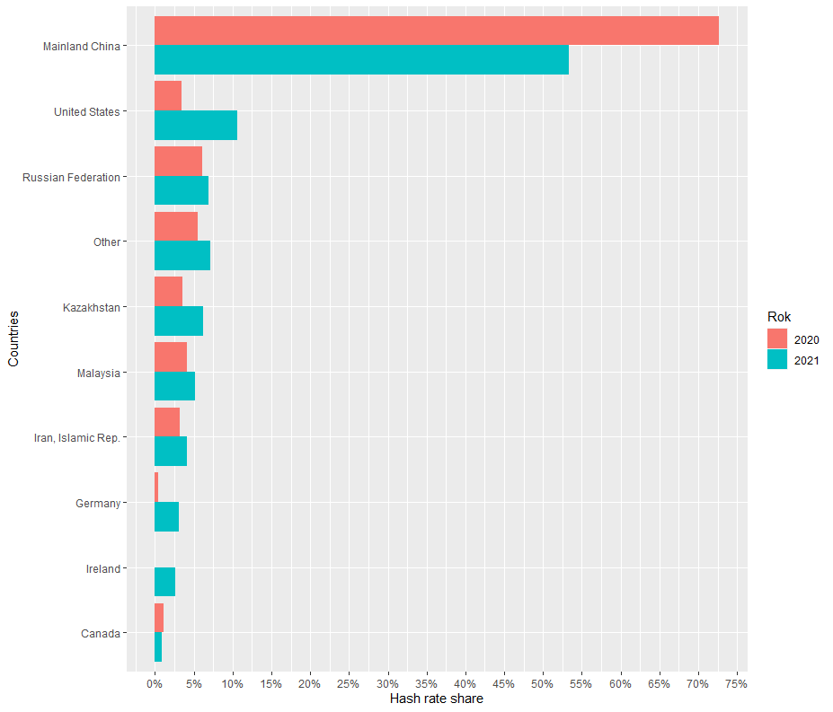

*Wykres 2.1*

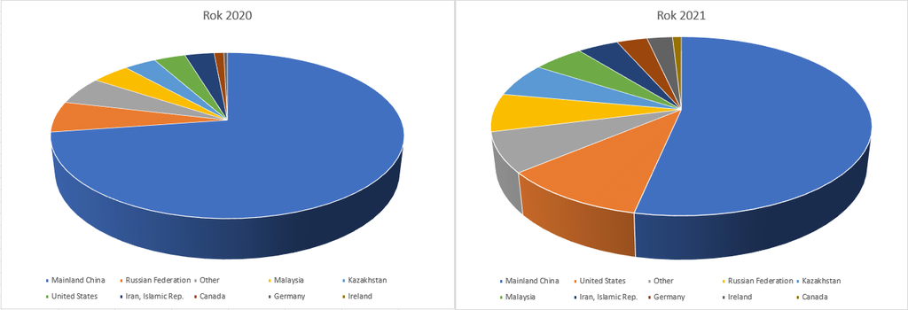

*Wykres 2.2*

**Celem esperymentu było:** zbadanie czy z wykresu kołowego 3D łatwo odczytać dane.

**Postawione pytanie ankeitowanym:** “W którym roku Rosja ma większy udział?”.

**Wyniki:** Poprawnie wybrało ok. 77% osób. Tabela obrazująca wyniki:

| Rok | Liczba osób |
| --- | --- |
| 2020 | 4 |
| 2021 | 13 |

**Wnioski:** wykresy kołowe 3D nie są wystarczająco czytelne.

**Uwagi ankietowanych** (pytanie: „Co ci przeszkadza w powyższym wykresie?”):

- Inny kolor tego samego państwa
- Brak konkretnego zestawienia Rosji z 2020 i 2021 roku
- niewidoczny jeden z kolorów
- Trójwymiarowość
- Nie ma informacji o %, wykres 3D

Po eksperymencie zadaliśmy pytanie “Czy wykres 2.1 lepiej obrazuje te dane?”, na które 17 osób (100%) wskazało, że Wykres 2.1 jest lepszą wizualizacją tych danych.

### Eksperyment 3

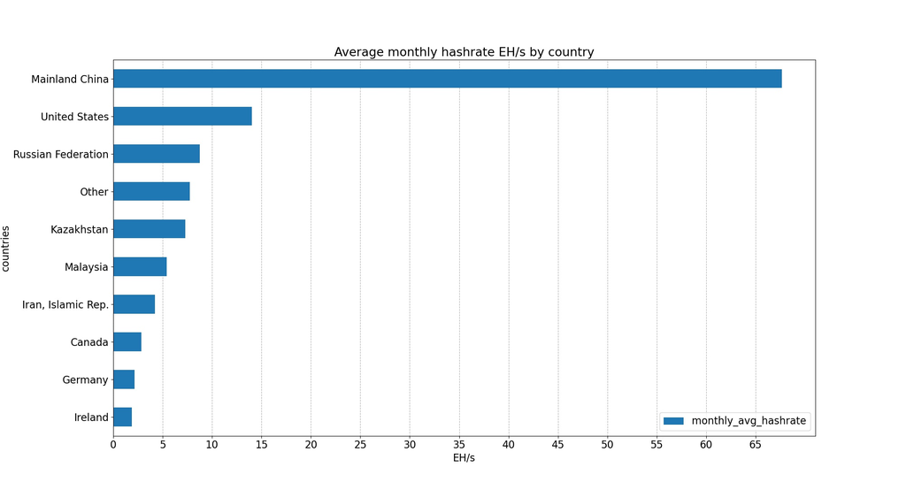

*Wykres 3.1*

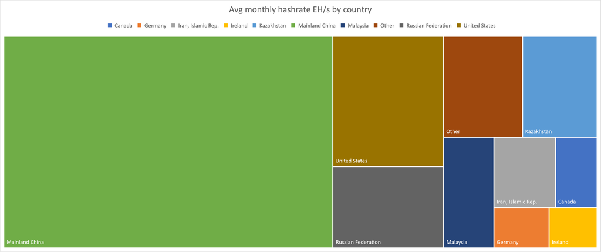

*Wykres 3.2*

**Celem esperymentu było:** Zbadanie czy z wykresu typu TreeMap łatwiej odczytać dane, niż z wykresu słupkowego.

**Postawione pytanie ankietowanym:** “Który wykres jest Twoim zdaniem czytelniejszy?”.

**Wyniki:** 16 osób wybrało wykres 3.1. Tabela obrazująca wybory ankietowanych:

| Nr wykresu | Liczba osób |
| --- | --- |
| 3.1 | 16 |
| 3.2 | 1 |

**Wnioski:** łatwiej odczytać dane z wykresu słupkowego.

## Podsumowanie

Z eksperymentów okazało się, że przyjęte dobre praktyki rzeczywiście mają sens, ponieważ w dużej większości ankietowani odpowiadali, że wykresy stworzone zgodnie z nimi są czytelniejsze.